# Alihan Zer - HW1

In this homework, the different datas are selected to be compared. These are: credit card expenses per year, dolar exchange rate per year, and consumer price index per year. The aim is, understanding the relationship between these three.

Credit cards are being used quite commonly in Turkey. They provide interest free loans for users. Therefore, it may be expected that the usage of credit cards may increase as the prices go up.

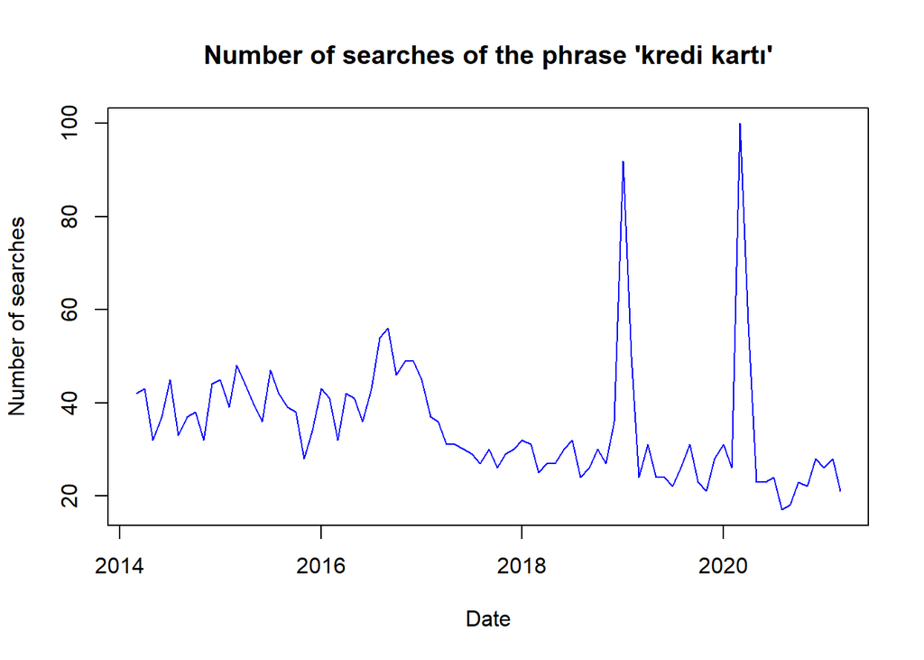

```r
cc <- read.csv("C:\\Users\\HP\\Desktop\\credit_card1.csv", header = TRUE, sep = ";")
cc$Tarih <- as.yearmon(cc$Tarih)
cc$Tarih <- as.POSIXct(cc$Tarih, format ="%d-%m-%y")
plot(cc$Tarih, cc$Miktar, col = "blue", type = "l", xlab = "Date", ylab = "Number of searches", main = "Number of searches of the phrase 'kredi kartı'")
```

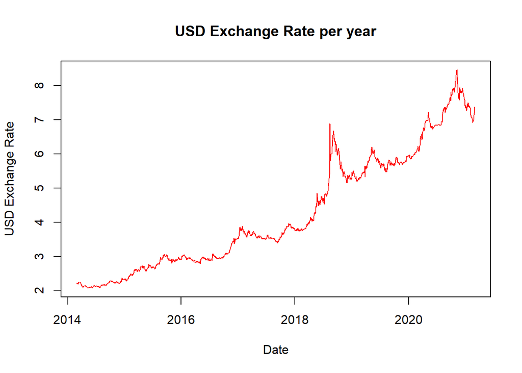

```r
usd <- read.csv("C:\\Users\\HP\\Desktop\\dollar.csv", header = TRUE, sep = ";")
dfusd <- get_series(series = c("TP.DK.USD.A.YTL"), start_date = "01-03-2014", end_date = "01-03-2021")
df2 <- dfusd$items
df2$UNIXTIME <- NULL
df2 <- df2[!is.na(df2$TP_DK_USD_A_YTL),]
df2$Tarih <- as.POSIXct(df2$Tarih, format="%d-%m-%Y")
df2$TP_DK_USD_A_YTL<- as.numeric(as.character.numeric_version(df2$TP_DK_USD_A_YTL))
plot(df2$Tarih, df2$TP_DK_USD_A_YTL, col="red", type = "l", xlab = "Date", ylab = "USD Exchange Rate", main = "USD Exchange Rate per year")
```

As expected, there is a sudden rise in 2018. The crisis happened in 2018 is known as “Turkish currency and debt crisis”. This crisis is still ongoing. Thus, we can observe more sudden rises and fall recently. Lately, Turkey is having hard times due to the pandemic. The pick at the end of the chart can be explained by this pandemic.

The sudden increase in 2018 caused people to search “dolar” in Google as well. Search volume of the word “dolar” and the USD/TRY exchange rate from 2014 to the crisis in 2018 looks similar. Up to that date, people had tendency to search the word “dolar” as the rate increased. However, after the tremendous increas in 2018, search volume started to go down. There may be couple reasons for this fall. First of which can be the exchange rate has increased relatively high in 2018. However, the rate of change of USD/TRY decreased, hence its search volume. Similarly, it can be seen that the 2021 crisis has caused the search volume to increase.

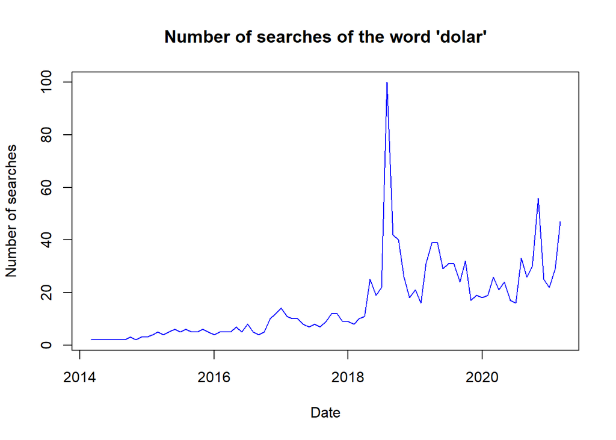

```r
usd$Ay<- as.yearmon(usd$Ay)
usd$Ay <- as.POSIXct(usd$Ay, format ="%d-%m-%y")
plot(usd$Ay, usd$dolar, col = "blue", type = "l", xlab = "Date", ylab = "Number of searches", main = "Number of searches of the word 'dolar'")
```

Having explained the first two, now the prices should be examined further. CPI, consumer price index, is the measure of the changes in overall prices.

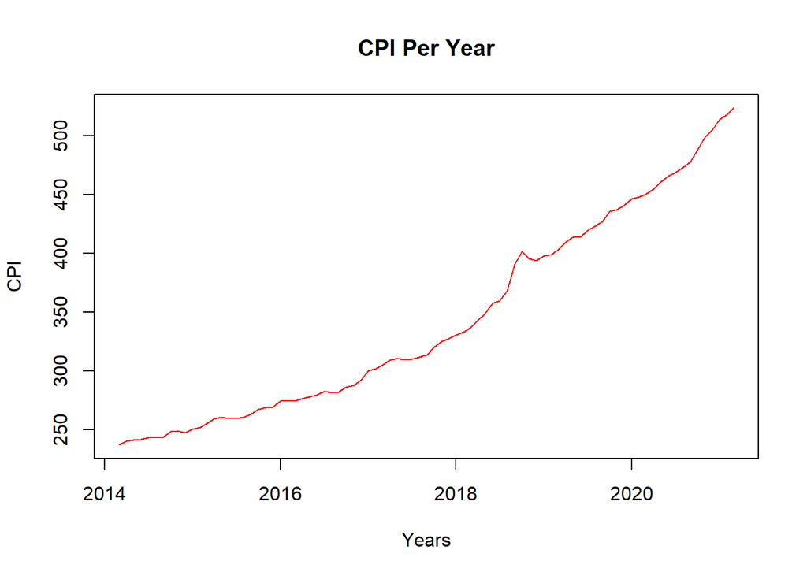

Unfortunately, there is not any surprises in this chart. It has a tendency to increase. In economic crisis, the overall prices are expected to increase. Thanks to this chart, it can be said that this expectation was appropriate.

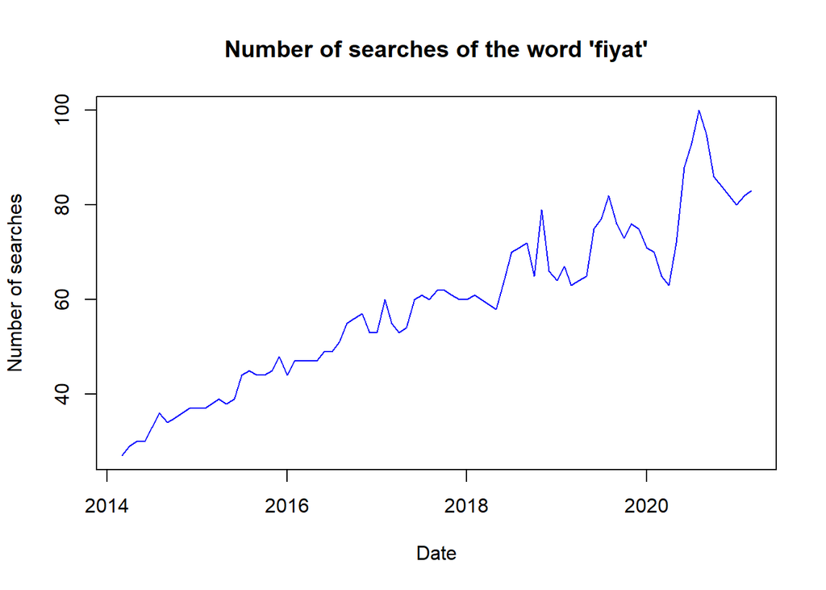

```r
cpi <- read.csv("C:\\Users\\HP\\Desktop\\cpi.csv", header = TRUE, sep = ";")
cpi$Ay <- as.yearmon(cpi$Ay)
cpi$Ay <- as.POSIXct(cpi$Ay, format ="%d-%m-%y")
plot(cpi$Ay, cpi$fiyat, col = "blue", type = "l", xlab = "Date", ylab = "Number of searches", main = "Number of searches of the word 'fiyat'")
```